# Презентация по лабораторной работе №6

Дисциплина: операционные системы

Лобанова П. И.

Российский университет дружбы народов, Москва, Россия

15.03.2023

# Информация

## Докладчик

- Лобанова Полина Иннокентьевна
- учащаяся факультета физико-математических и естественных наук
- учащаяся направления “Математика и механика”
- Российский университет дружбы народов
- polla-2004@mail.ru

# Цель работы

Ознакомление с инструментами поиска файлов и фильтрации текстовых данных. Приобретение практических навыков: по управлению процессами (и заданиями), по проверке использования диска и обслуживанию файловых систем.

# Ход работы

## Запись в файл

Для того, чтобы записать результат вводимой команды в файл, а не просто вывести на экран, необходимо после самой команды ввести символы “>” (“>>”), а после имя файла, в который это будет записано.

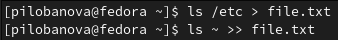

*Запись в файл.*

## Поиск файлов

Для того, чтобы найти файл (или директорию) с определенным символом в названии, используется команда find.

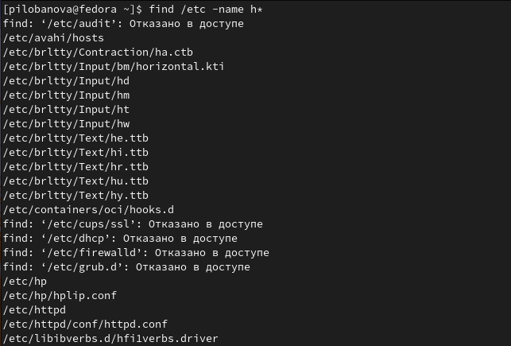

*Команда find.*

## Фильтрация текста

Для того, чтобы найти необходимые слова (или строчки) в файлах, используется команда grep.

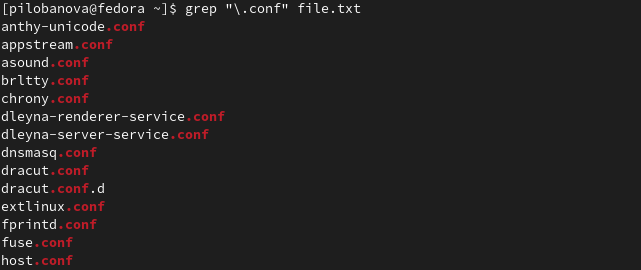

*Команда grep.*

## Проверка использования диска

Команда du отображает число килобайтов, которое занимает тот или иной файл. Команда df отображает размер каждого смонтированного диска.

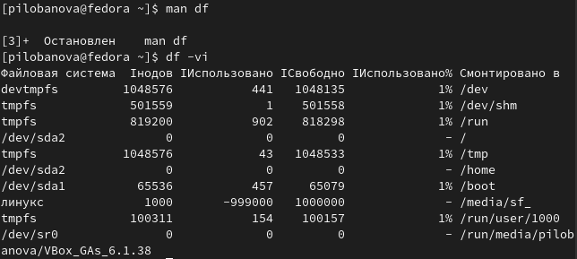

*Команда df.*

## Управление процессами

Для того, чтобы запустить какой-либо процесс в фоновом режиме, после введенной команды необходимо поставить символ “&”.

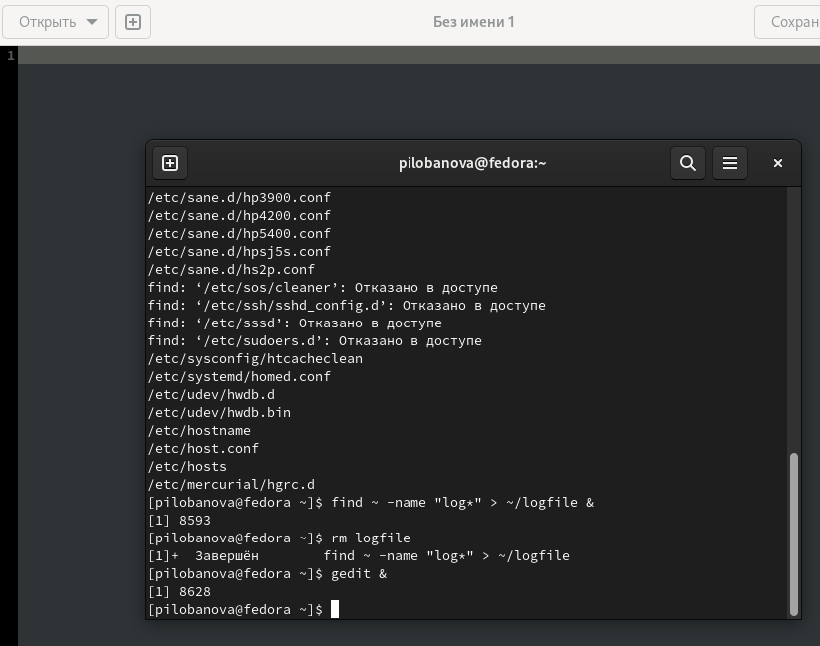

*Команда с “&”.*

## Контрольные вопросы

1. Какие потоки ввода вывода вы знаете?
2. Объясните разницу между операцией > и >>.
3. Что такое конвейер?
4. Что такое процесс? Чем это понятие отличается от программы?
5. Что такое PID и GID?
6. Что такое задачи и какая команда позволяет ими управлять?
7. Найдите информацию об утилитах top и htop. Каковы их функции?
8. Назовите и дайте характеристику команде поиска файлов. Приведите примеры использования этой команды.
9. Можно ли по контексту (содержанию) найти файл? Если да, то как?
10. Как определить объем свободной памяти на жёстком диске?
11. Как определить объем вашего домашнего каталога?
12. Как удалить зависший процесс?

# Вывод

Я ознакомилась с инструментами поиска файлов и фильтрации текстовых данных, приобрела практические навыки по управлению процессами, по проверке использования диска и по обслуживанию файловых систем.